# Integrated excercise

## Subtask 2.2: did the model converge properly?

Perform different checks on the convergence of the model.

*Possible solution*

Let’s start by checking the trace-plots.

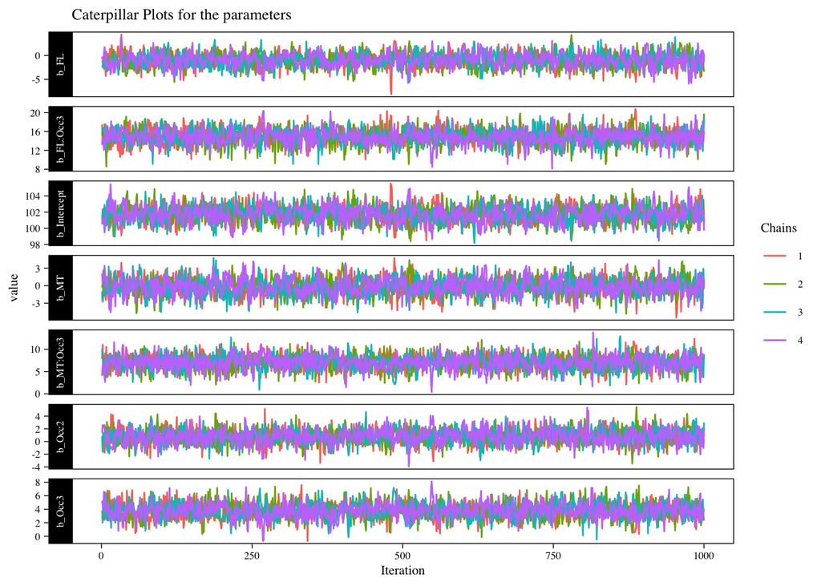

```r
library(ggmcmc)

Model_chains <- ggs(M3b)

Model_chains %>%
  filter(Parameter %in% c(
    "b_Intercept",
    "b_FL",
    "b_MT",
    "b_Occ2",
    "b_Occ3",
    "b_FL:Occ2",
    "b_FL:Occ3",
    "b_MT:Occ2",
    "b_MT:Occ3"
    )
  ) %>%
  ggplot(aes(
    x   = Iteration,
    y   = value,
    col = as.factor(Chain)))+
  geom_line() +
  facet_grid(Parameter ~ .,
             scale  = 'free_y',
             switch = 'y') +
  labs(title = "Caterpillar Plots for the parameters",
       col   = "Chains")
```

Looking at the trace-plots, we can conclude that all chains mixed very well. This is already a first indication of successful convergence.

Next, we can check the R-hat statistic for each of the parameters. With the following plot we get a visual overview of all the R-hat statistics (notice the large number of parameters, because we also have random effects in our model):

**Note**

In the code below you can see that I first create a vector called `Rhats` to use in the `mcmc_rhat()` function. To create the vector I call the `brms::rhat()` function. By writing explicitly `brms::` before the `rhat()` I make sure that the `rhat()` function from the package `brms` is used. I do this to avoid the use of another `rhat()` function that might be loaded by activating other packages and that results in incompatible results with the `mcmc_rhat()` function.

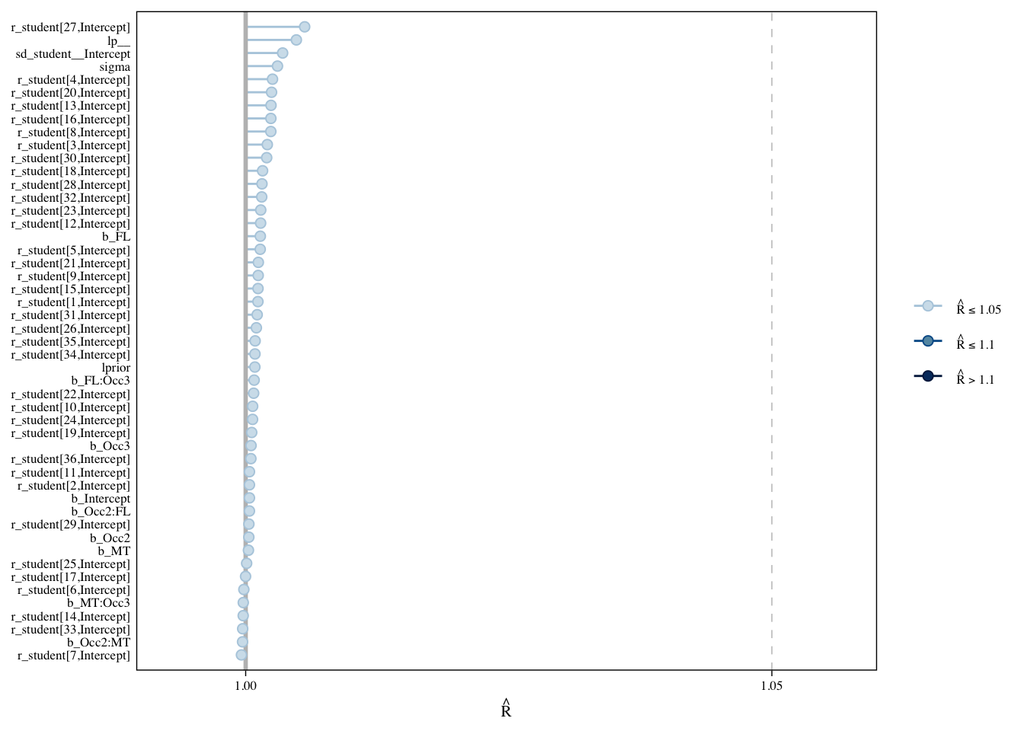

```r
library(brms)
library(bayesplot)

# Extract posterior draws as array (robust method)
Rhats <- brms::rhat(M3b)

# Plot with bayesplot
mcmc_rhat(Rhats, size = 2) +
  yaxis_text(hjust = 1)
```

None of the parameters shows a high R-hat statistic. They all are below the threshold of 1.05, indicating that all parameters converged well.

Time to get insight in the amount of autocorrelation. A first check is plotting the ratio of the number of *Effective Sample Sizes* to the *Total Sampel Sizes* for all the parameters. Remember that this ratio should be above 0.1 to be sure that the amount of autocorrelation is acceptable. Following code gives a visual overview of these ratios.

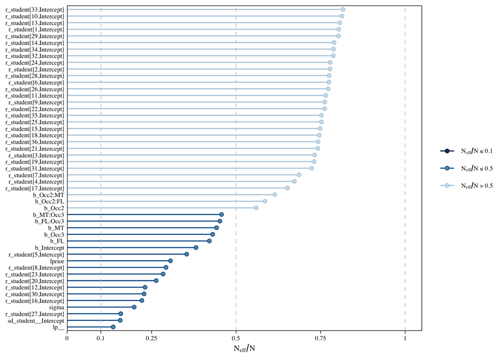

```r
mcmc_neff(
  neff_ratio(M3b)
  ) +
  yaxis_text(hjust = 1)
```

From the plot we learn that for all the parameters the ratio is above 0.1. So, we can conclude that the amount of autocorrelation is not problematic for the estimation of any of the parameters.

## Subtask 2.3: does the posterior distribution histogram have enough information?

Check if the posterior distribution histograms of the different parameters are informative enough to substantiate our inferences.

*Possible solution*

To evaluate this, we create histograms based on the draws for our parameter values based on our model. We will apply this first for all main fixed effects.

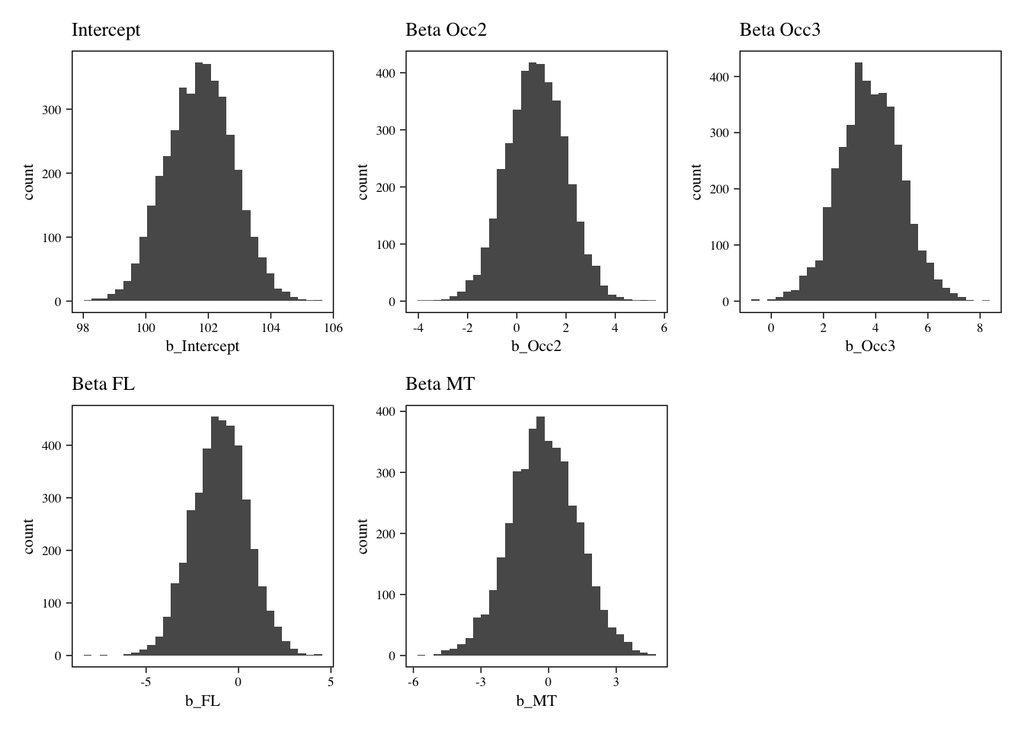

```r
library(patchwork)

posterior_PD <- as_draws_df(M3b)

post_intercept <-
  posterior_PD %>%
  select(b_Intercept) %>%
  ggplot(aes(x = b_Intercept)) +
  geom_histogram() +
  ggtitle("Intercept")

post_Occ2 <-
  posterior_PD %>%
  select(b_Occ2) %>%
  ggplot(aes(x = b_Occ2)) +
  geom_histogram() +
  ggtitle("Beta Occ2")

post_Occ3 <-
  posterior_PD %>%
  select(b_Occ3) %>%
  ggplot(aes(x = b_Occ3)) +
  geom_histogram() +
  ggtitle("Beta Occ3")

post_FL <-
  posterior_PD %>%
  select(b_FL) %>%
  ggplot(aes(x = b_FL)) +
  geom_histogram() +
  ggtitle("Beta FL")

post_MT <-
  posterior_PD %>%
  select(b_MT) %>%
  ggplot(aes(x = b_MT)) +
  geom_histogram() +
  ggtitle("Beta MT")


post_intercept + post_Occ2 + post_Occ3 + post_FL + post_MT +
  plot_layout(ncol = 3)
```

These plots show clear slopes and a peak, indicating that the posterior is informative enough for each of these parameters.

Now, let’s do the same for the interaction effects.

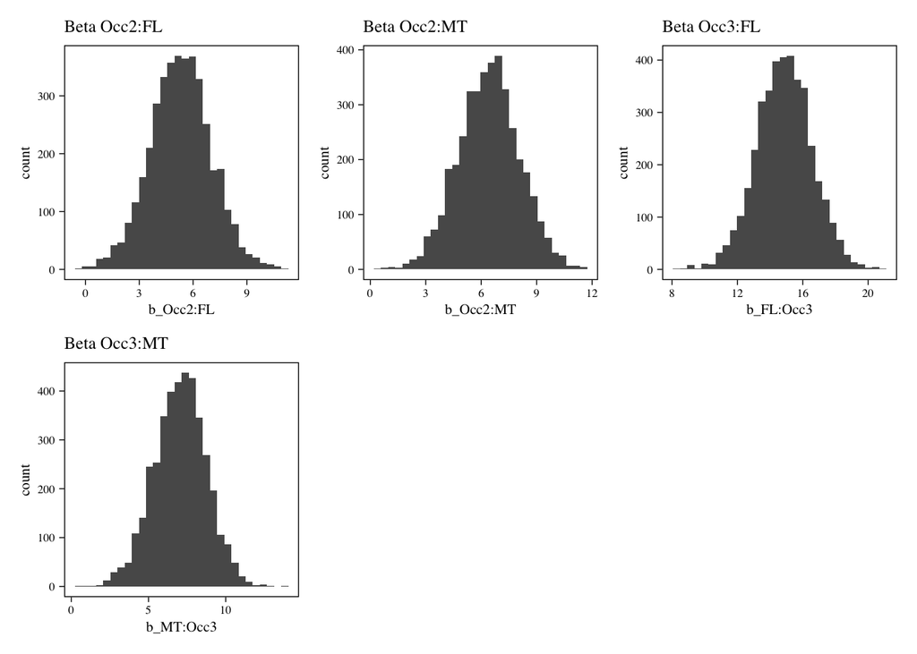

```r
post_Occ2_FL <-
  posterior_PD %>%
  select(`b_Occ2:FL`) %>%
  ggplot(aes(x = `b_Occ2:FL`)) +
  geom_histogram() +
  ggtitle("Beta Occ2:FL")

post_Occ2_MT <-
  posterior_PD %>%
  select(`b_Occ2:MT`) %>%
  ggplot(aes(x = `b_Occ2:MT`)) +
  geom_histogram() +
  ggtitle("Beta Occ2:MT")

post_Occ3_FL <-
  posterior_PD %>%
  select(`b_FL:Occ3`) %>%
  ggplot(aes(x = `b_FL:Occ3`)) +
  geom_histogram() +
  ggtitle("Beta Occ3:FL")

post_Occ3_MT <-
  posterior_PD %>%
  select(`b_MT:Occ3`) %>%
  ggplot(aes(x = `b_MT:Occ3`)) +
  geom_histogram() +
  ggtitle("Beta Occ3:MT")

post_Occ2_FL + post_Occ2_MT + post_Occ3_FL + post_Occ3_MT +
  plot_layout(ncol = 3)
```

Here the conclusion is the same. These histograms show no problematic cases.

## Subtask 2.4: how well does the model predict the observed data?

Perform posterior predictive checks based on the model.

*Possible solutions*

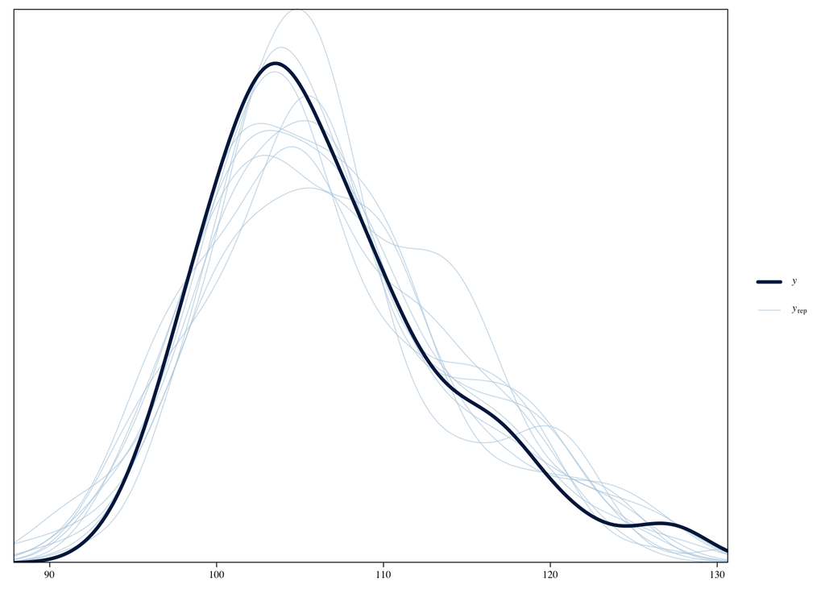

```r
pp_check(M3b)
```

Looking at the posterior probability checks, we can see that the distributions of simulated data show a strong resemblance to the distribution of the observed data. So, the conclusion could be that our model is performing quiet well.

## Subtask 2.5: what about prior sensitivity of the results?

Finally, we have to check if the results of our model are not too dependent on the priors we specified in the model.

```r
library(priorsense)

powerscale_sensitivity(M3b)
```

```
Sensitivity based on cjs_dist:
# A tibble: 47 × 4
   variable               prior likelihood diagnosis
   <chr>                  <dbl>      <dbl> <chr>
 1 b_Intercept           0.0880      0.150 prior-data conflict
 2 b_Occ2                0.101       0.242 prior-data conflict
 3 b_FL                  0.110       0.166 prior-data conflict
 4 b_MT                  0.0808      0.138 prior-data conflict
 5 b_Occ3                0.127       0.276 prior-data conflict
 6 b_Occ2:FL             0.129       0.285 prior-data conflict
 7 b_Occ2:MT             0.108       0.271 prior-data conflict
 8 b_FL:Occ3             0.153       0.372 prior-data conflict
 9 b_MT:Occ3             0.116       0.272 prior-data conflict
10 sd_student__Intercept 0.0192      0.719 -
# ℹ 37 more rows
```

We learn from this prior sensitivity analyses that there is a *prior-data conflict*.

**Note**

If we delve into the paper on the `priorsense` package we can read this paragraph:

> Prior-data conflict (Evans & Moshonov, 2006; Nott, Wang, et al., 2020; Walter & Augustin, 2009) can arise due to intentionally or unintentionally informative priors disagreeing with, but not being dominated by, the likelihood. When this is the case, the posterior will be sensitive to power-scaling both the prior and the likelihood, as illustrated in Figure 5. When prior-data conflict has been detected, the modeller may wish to modify the model by using a less informative prior (e.g., Evans & Jang, 2011; Nott, Seah, et al., 2020) or using heavy-tailed distributions (e.g., Gagnon, 2022; O’Hagan & Pericchi, 2012).

Reference: Kallioinen, N., Paananen, T., Bürkner, P.-C., & Vehtari, A. (2023). Detecting and diagnosing prior and likelihood sensitivity with power-scaling. Statistics and Computing, 34(1), 57. https://doi.org/10.1007/s11222-023-10366-5

So, it might imply that our priors are “unintentionally informative”. Let’s see what happens if we would stick to the default priors of `brms`. Given that the object called `M3` contains the estimation of the model using the default priors we can quickly learn about the prior sensitivity of this model.

```r
powerscale_sensitivity(M3)
```

```
Sensitivity based on cjs_dist:
# A tibble: 47 × 4
   variable                 prior likelihood diagnosis
   <chr>                    <dbl>      <dbl> <chr>
 1 b_Intercept           0.00283      0.0603 -
 2 b_Occ2                0.000612     0.128  -
 3 b_FL                  0.00104      0.0596 -
 4 b_MT                  0.00118      0.0606 -
 5 b_Occ3                0.000393     0.124  -
 6 b_Occ2:FL             0.000629     0.147  -
 7 b_Occ2:MT             0.000578     0.142  -
 8 b_FL:Occ3             0.000427     0.137  -
 9 b_MT:Occ3             0.000400     0.127  -
10 sd_student__Intercept 0.00617      0.502  -
# ℹ 37 more rows
```

Looking at this prior sensitivity check we learn that using the default priors makes the model less sensitive to the priors used!

“What to do now?”

Well, in my opinion there is not a single best way to deal with this situation. What I would do first is compare the results based on both models (`M3` and `M3b`). Let’s print the parameter estimates of both models. To do this I rely on the `tab_model()` function from the very helpful package `sjPlot` (so, do not forget to install that one if you want to use it!), as it allows me to show the results of both models side-to-side.

[output not shown]

This table clearly demonstrates how the model making use of the default priors has different results than the model with the priors we had set ourselves!

If we think about this more profoundly this doesn’t have to come as a surprise! The priors used for the effect of Occasion was maybe nonsense. Why not assuming that students got more fluent over the time course of 26 weeks? To be fairly honest, I deliberately used these priors that seemed uninformative so that we would - for didactical reasons - run into this issue!

For the rest of the exercise we will stick to the results of the model with default priors. But, another option could be to change our custom priors, mimicking the idea that we expect students to become more fluent on the course of 26 weeks. That’s what I actually did in a blogpost that I wrote about using the `priorsense` package that can be found here: https://sdemaeyer.quarto.pub/posts/2024-02-PriorSense/PriorSensePost.html

# 3. Task 3

Now a more general task. Make different visualizations of the model results.

One of the possible visualizations could be a rather complex one. Remember, there are 3 conditions and 3 occasions. What I like to see is a plot showing the expected means for each of the conditions on each of the 3 occasions.

And what do we learn about the progress between Occ1 and Occ2 in each of the groups? And what about the progress between Occ2 and Occ3?

*Possible solution*

Let’s start tackling this challenge:

|“One of the possible visualizations could be a rather complex one. Remember, there are 3 conditions and 3 occasions. What I like to see is a plot showing the expected means for each of the conditions on each of the 3 occasions.”

Starting point: create an object containing the draws from the posterior based on model M3.

```r
posterior_M3 <- as_draws_df(M3)
```

The next step is calculating some predicted means, based on combinations of our dummy variables in the model. This is a ‘tricky’ step because we have to keep in mind that the model also contains interaction effects.

```r
posterior_M3 <- posterior_M3 %>%
  mutate(

    # calculate expected mean for Occ1 condition NoSub (that's just our intercept)
    Occ1_NoSub = b_Intercept,
    # calculate expected mean for Occ1 condition FL (add main effect of FL)
    Occ1_FL = b_Intercept + b_FL,
    # calculate expected mean for Occ1 condition MT (add main effect of MT)
    Occ1_MT = b_Intercept + b_MT,

    # calculate expected mean for Occ2 condition NoSub (add main effect of Occ2)
    Occ2_NoSub = b_Intercept + b_Occ2,
    # calculate expected mean for Occ2 condition FL (add main effects and interaction term)
    Occ2_FL = b_Intercept + b_Occ2 + b_FL + `b_Occ2:FL`,
    # calculate expected mean for Occ2 condition MT (add main effects and interaction term)
    Occ2_MT = b_Intercept + b_Occ2 + b_MT + `b_Occ2:MT`,

    # calculate expected mean for Occ3 condition NoSub (add main effect of Occ2)
    Occ3_NoSub = b_Intercept + b_Occ3,
    # calculate expected mean for Occ3 condition FL (add main effects and interaction term)
    Occ3_FL = b_Intercept + b_Occ3 + b_FL + `b_FL:Occ3`,
    # calculate expected mean for Occ3 condition MT (add main effects and interaction term)
    Occ3_MT = b_Intercept + b_Occ3 + b_MT + `b_MT:Occ3`

  )
```

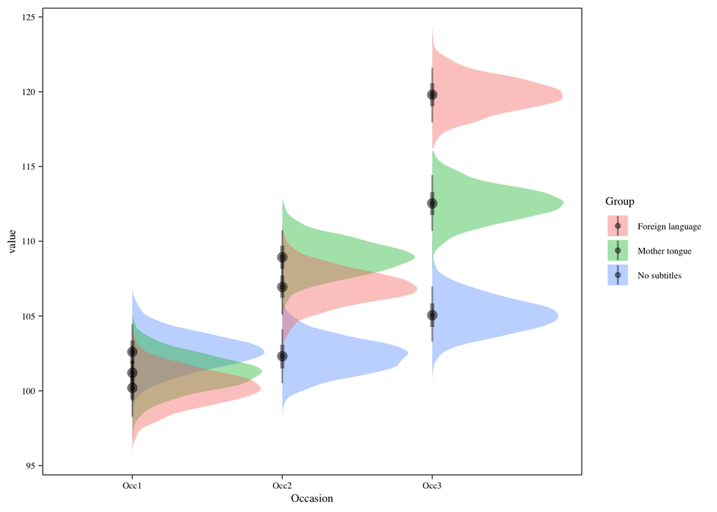

```r
library(ggplot2)
library(ggdist)

posterior_M3 %>%

  # First: select only the relevant columns of our posterior draws object
  select(
    Occ1_NoSub, Occ1_FL, Occ1_MT,
    Occ2_NoSub, Occ2_FL, Occ2_MT,
    Occ3_NoSub, Occ3_FL, Occ3_MT,
  ) %>%

  # Second: pivot everything longer to get two columns
  # column called `name` containing the name of the parameter
  # calumn called `value` containing the value for that parameter in that draw
  pivot_longer(everything()) %>%

  # Now create new variable that indicates the Occasion because I want to use that as X-axis
  # And create new variable that indicates the group (NoSub, MT, or FL) to make groups in the plot
  mutate(
    Occasion = case_when(
      name == "Occ1_NoSub" | name == "Occ1_FL" | name == "Occ1_MT" ~ "Occ1",
      name == "Occ2_NoSub" | name == "Occ2_FL" | name == "Occ2_MT" ~ "Occ2",
      name == "Occ3_NoSub" | name == "Occ3_FL" | name == "Occ3_MT" ~ "Occ3",
    ),
    Group = case_when(
      name == "Occ1_NoSub" | name == "Occ2_NoSub" | name == "Occ3_NoSub" ~ "No subtitles",
      name == "Occ1_FL"    | name == "Occ2_FL"    | name == "Occ3_FL"    ~ "Foreign language",
      name == "Occ1_MT"    | name == "Occ2_MT"    | name == "Occ3_MT"    ~ "Mother tongue",
    )
  ) %>%

  # Time to create the plot
  ggplot(
    aes(x = Occasion,
        y = value,
        group = Group,
        fill = Group)  # identify the experimental groups by the fill color
  ) +
  stat_halfeye(
    .width = c(.5, .89),
    alpha = .4 # make the fill color of the density plots more transparent
  )
```

The next challenge:

|“And what do we learn about the progress between Occ1 and Occ2 in each of the groups? And what about the progress between Occ2 and Occ3? Is progress between two occasions different in each of the conditions?”

These questions can be compared with using tests on *estimated marginal means* and post-hoc testing by making use of contrasts in the frequentist realm.

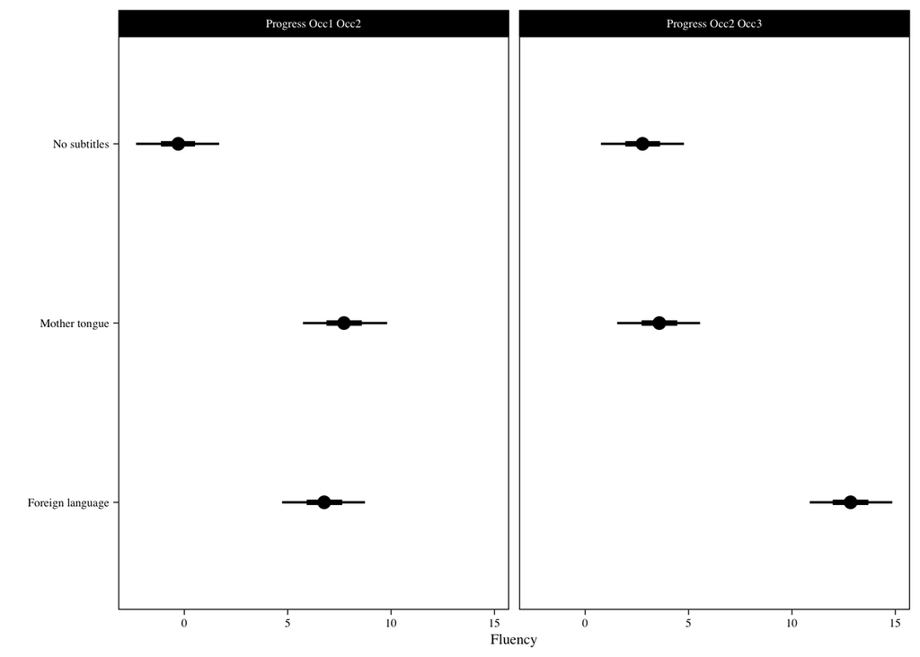

```r
# Start by creating difference scores between occasions based on draws

posterior_M3 <- posterior_M3 %>%
  mutate(

    # Difference between occasions for condition NoSub
    Occ2_Occ1_NoSub = Occ2_NoSub - Occ1_NoSub,
    Occ3_Occ2_NoSub = Occ3_NoSub - Occ2_NoSub,

    # Difference between occasions for condition FL
    Occ2_Occ1_FL = Occ2_FL - Occ1_FL,
    Occ3_Occ2_FL = Occ3_FL - Occ2_FL,

    # Difference between occasions for condition MT
    Occ2_Occ1_MT = Occ2_MT - Occ1_MT,
    Occ3_Occ2_MT = Occ3_MT - Occ2_MT

  )

# Create the visualisation

posterior_M3 %>%

  # select only the relevant columns for creating the plot
  select(
    Occ2_Occ1_NoSub, Occ3_Occ2_NoSub,
    Occ2_Occ1_FL, Occ3_Occ2_FL,
    Occ2_Occ1_MT, Occ3_Occ2_MT,
  ) %>%

  # do the pivot_longer to create one vector of values and a vector of parameter names
  pivot_longer(
    everything( )
    ) %>%

 # Create variables that help identify groups of parameters to color the distributions
  mutate(
    Occasion = case_when(
      name == "Occ2_Occ1_NoSub" | name == "Occ2_Occ1_FL" | name == "Occ2_Occ1_MT" ~ "Progress Occ1 Occ2",
      name == "Occ3_Occ2_NoSub" | name == "Occ3_Occ2_FL" | name == "Occ3_Occ2_MT" ~ "Progress Occ2 Occ3"),
    Group = case_when(
      name == "Occ2_Occ1_NoSub" | name == "Occ3_Occ2_NoSub"  ~ "No subtitles",
      name == "Occ2_Occ1_FL" | name == "Occ3_Occ2_FL"  ~ "Foreign language",
      name == "Occ2_Occ1_MT" | name == "Occ3_Occ2_MT"  ~ "Mother tongue",
    )
  ) %>%

  ggplot(
    aes(
      x = value,
      y = Group
    )
  ) +

  # Let's plot interval visualisations

  stat_pointinterval(
    .width = c(.5, .89)
    ) +
  scale_y_discrete(name = "") +           # Drop the label of the y-scale
  scale_x_continuous(name = "Fluency") +  # Name the x-scale
  facet_wrap(.~Occasion)
```

From this visualisation we learn that the progress between occasion 1 and 2 is rather similar in both subtitle groups (intervals strongly overlap). The students in the condition without subtitles make a smaller progress between occasion 1 and occasion 2 than the students in both subtitling conditions.

Focussing on the progress between occasion 2 and 3, we see that the progress of the students in the foreign language subtitling condition stands out from the progress made in the two other conditions.

```r
hypothesis(
  posterior_M3,
  hypothesis = "Occ2_Occ1_MT > Occ2_Occ1_FL"
)
```

```
Hypothesis Tests for class :
                Hypothesis Estimate Est.Error CI.Lower CI.Upper Evid.Ratio
1 (Occ2_Occ1_MT)-(O... > 0     0.98       1.8    -1.98     3.96        2.4
  Post.Prob Star
1      0.71
---
'CI': 90%-CI for one-sided and 95%-CI for two-sided hypotheses.
'*': For one-sided hypotheses, the posterior probability exceeds 95%;
for two-sided hypotheses, the value tested against lies outside the 95%-CI.
Posterior probabilities of point hypotheses assume equal prior probabilities.
```

If we wrap this `hypothesis()` part within a `plot()` function, we get a visualization of the posterior probability distribution of the difference in progress for the two subtitling conditions.

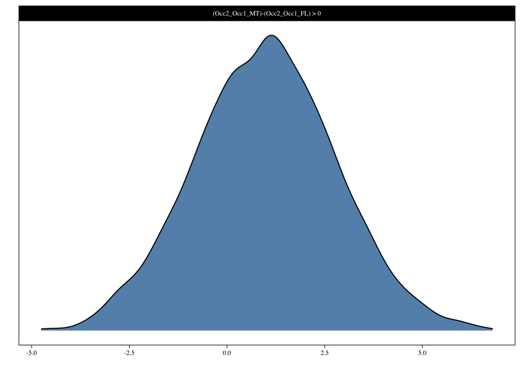

```r
plot(
  hypothesis(
    posterior_M3,
    hypothesis = "Occ2_Occ1_MT > Occ2_Occ1_FL"
    )
)
```

This visualization shows that a great amount of credible estimates of this difference in progress between both subtitling conditions is situated around zero, with high probabilities for both a negative and positive difference. In other words, most of the evidence shows that we are not sure to state whether both subtitling conditions differ in the progress in fluency they induced between occasion 1 and occasion 2.

Now, let’s focus on the difference between occasion 2 and occasion 3: how much evidence is there that this progress is stronger in the condition of foreign language subtitling compared to the condition of mother tongue subtitling?

```r
hypothesis(
  posterior_M3,
  hypothesis = "Occ3_Occ2_FL > Occ3_Occ2_MT"
)
```

```
Hypothesis Tests for class :
                Hypothesis Estimate Est.Error CI.Lower CI.Upper Evid.Ratio
1 (Occ3_Occ2_FL)-(O... > 0     9.26      1.77     6.31    12.15        Inf
  Post.Prob Star
1         1    *
---
'CI': 90%-CI for one-sided and 95%-CI for two-sided hypotheses.
'*': For one-sided hypotheses, the posterior probability exceeds 95%;
for two-sided hypotheses, the value tested against lies outside the 95%-CI.
Posterior probabilities of point hypotheses assume equal prior probabilities.
```

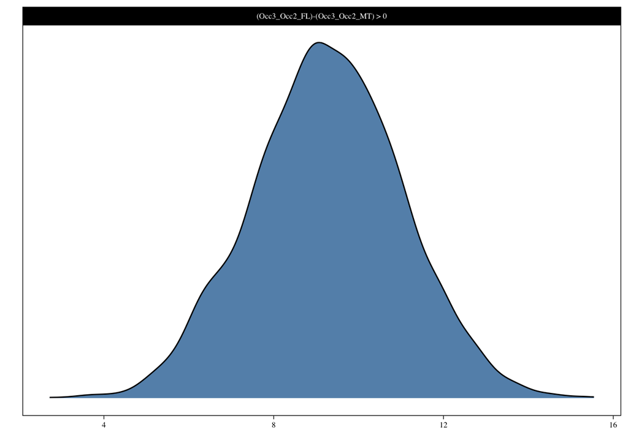

```r
plot(
 hypothesis(
  posterior_M3,
  hypothesis = "Occ3_Occ2_FL > Occ3_Occ2_MT"
 )
)
```

Here we can see that we have a lot of supporting evidence to conclude that the improvement between occasion 2 and 3 in fluency is stronger for the students in the foreign language condition than for the students in the mother tongue condition.

Back to top

## References

Frumuselu, Anca Daniela, Sven De Maeyer, Vincent Donche, and María del Mar Gutiérrez Colon Plana. 2015. “Television Series Inside the EFL Classroom: Bridging the Gap Between Teaching and Learning Informal Language Through Subtitles.” *Linguistics and Education* 32 (December): 107–17. https://doi.org/10.1016/j.linged.2015.10.001.